# dapR2 live analysis

Tom Booth

26/10/2020

# dapR2 live analyses

There are two live analysis session in dapR2, one at the end of each 5 week block.

In the first session, we will look at data cleaning and checks (incl. visualisation), and run some simple linear models with assumption checks (q1 and q2 below). In the second session, we will expand the analyses to look at linear models with multiple predictors and interactions (q3 to q5 below). This markdown file will be made available after the session and you can edit and explore as much as you like.

# Task

A research team are interested improving driver safety. They are interested in how risky driving behaviour is influenced by characteristics of individuals and their interactions with environmental stimuli and substance use. One of the studies in the research project involves the relation between alcohol and marijuana use and risky behaviour.

In this study, participants are randomly assigned to one of four conditions (control, low alcohol, high alcohol and marijuana; n=20). All participants were male, had been driving for between 3-5 years, drove on average for 10 hours per week (self-reported) and had never been convicted by the police for any driving offences. Participants were recruited evenly across two age groups (young 18-25) and old (50-60), with 10 young and 10 old participants in each of the experimental groups.

Participants were asked to complete a 20 minute driving simulation in which various dangers and situations arise in which participants must make decisions on how to act quickly. The decisions participants make are scored based on the degree of risky behaviour they represent. The research team have also measured a host of other variables, some demographic, some as focal covariates.

The research team would like to answer the following questions:

1. Does increased impulsivity lead to an increase in risky driving behaviours? (week 5)
2. Are there differences between young and old participants in risky driving behaviour? (week 5)
3. Are there differences in risky driving behaviour across experimental conditions? (week 10)
4. Do the differences across experimental conditions remain the same after controlling for weight and impulsivity? (week 10)
5. Does the effect of impulsivity on risking driving behaviour change as a function of age? (week 10)

Using the data described in the table below and available (in **.csv** format) at [LINK](https://uoepsy.github.io/data/RMS2_data.csv), conduct, interpret and write up a set of analyses that answer the researcher’s research question. You can read the data into R direct from the following address “https://uoepsy.github.io/data/RMS2_data.csv”

| variable | description |
| --- | --- |
| ID | Unique participant identifier |
| drive | Driving risk taking score. Range: 0 to 100. Higher scores = increased risk taking |
| weight | Weight in kg’s |
| impulsivity | Z-score from self-report survey. Higher scores = higher impulsivity |
| age | Ordered category: Young vs Old |
| condition | Experimental Condition: 0= control; 1 = low alcohol; 2 = high alcohol; 3 = marijuana |

# Analysis

## Read in the data

```r
library(tidyverse)
```

```r
tib <- read_csv("https://uoepsy.github.io/data/RMS2_data.csv", col_types = "cdddff")
```

```r
tib
```

```
## # A tibble: 80 x 6
##    ID      drive weight impulsivity Age   Condition
##    <chr>   <dbl>  <dbl>       <dbl> <fct> <fct>
##  1 RMS2101    39     81        1    Young 0
##  2 RMS2102    29     86        0.55 Young 0
##  3 RMS2103    47     88        0.5  Young 0
##  4 RMS2104    39     86        0.67 Young 0
##  5 RMS2105    48     93        0.37 Young 0
##  6 RMS2106    33     88       -0.19 Young 0
##  7 RMS2107    36     77       -0.35 Young 0
##  8 RMS2108    30     88        0.55 Young 0
##  9 RMS2109    29     83       -0.73 Young 0
## 10 RMS2110    62     87        1.84 Young 0
## # ... with 70 more rows
```

## Data checks

```r
tib2 <- tib %>%
  select(ID, drive, impulsivity, Age)
tib2
```

```
## # A tibble: 80 x 4
##    ID      drive impulsivity Age
##    <chr>   <dbl>       <dbl> <fct>
##  1 RMS2101    39        1    Young
##  2 RMS2102    29        0.55 Young
##  3 RMS2103    47        0.5  Young
##  4 RMS2104    39        0.67 Young
##  5 RMS2105    48        0.37 Young
##  6 RMS2106    33       -0.19 Young
##  7 RMS2107    36       -0.35 Young
##  8 RMS2108    30        0.55 Young
##  9 RMS2109    29       -0.73 Young
## 10 RMS2110    62        1.84 Young
## # ... with 70 more rows
```

```r
tib2 %>%
  summarise(
    Mean = mean(impulsivity),
    Sd = sd(impulsivity),
    Min = min(impulsivity),
    Max = max(impulsivity)
  )
```

```
## # A tibble: 1 x 4
##      Mean    Sd   Min   Max
##     <dbl> <dbl> <dbl> <dbl>
## 1 -0.0155  1.18 -3.38  2.92
```

```r
tib2 %>%
  summarise(
    Mean = mean(drive, na.rm=T),
    Sd = sd(drive, na.rm=T),
    Min = min(drive, na.rm=T),
    Max = max(drive, na.rm=T)
  )
```

```
## # A tibble: 1 x 4
##    Mean    Sd   Min   Max
##   <dbl> <dbl> <dbl> <dbl>
## 1  42.9  11.4    17    70
```

```r
table(tib2$Age)
```

```
##
## Young   Old
##    40    40
```

## Visualization

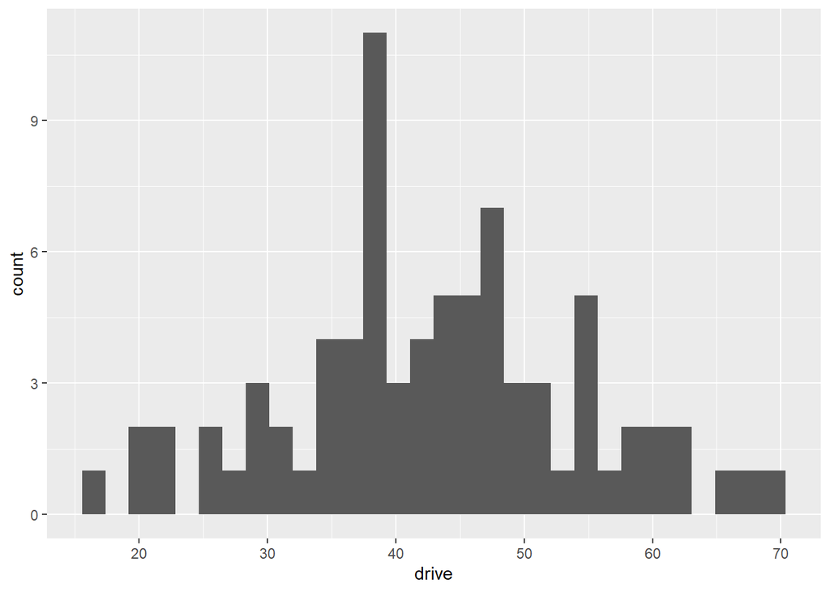

```r
tib2 %>%
  ggplot(., aes(x=drive)) +
  geom_histogram()
```

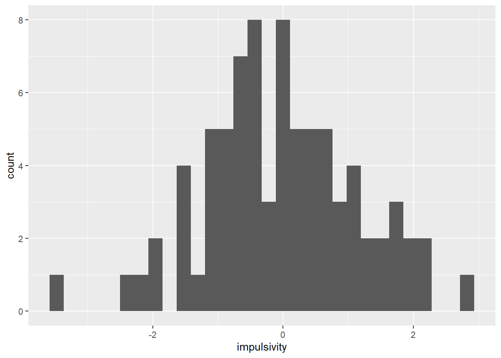

```r
tib2 %>%
  ggplot(., aes(x=impulsivity)) +
  geom_histogram()
```

## Question 1

1. Does increased impulsivity lead to an increase in risky driving behaviours? (week 5)

```r
m1 <- lm(drive ~ impulsivity, data = tib2)
summary(m1)
```

```
##
## Call:
## lm(formula = drive ~ impulsivity, data = tib2)
##
## Residuals:
##      Min       1Q   Median       3Q      Max
## -20.3864  -7.9213   0.6384   8.2834  19.7914
##
## Coefficients:
##             Estimate Std. Error t value Pr(>|t|)
## (Intercept)  43.1954     1.0967  39.388  < 2e-16 ***
## impulsivity   5.3935     0.9715   5.552 3.86e-07 ***
## ---
## Signif. codes:  0 '***' 0.001 '**' 0.01 '*' 0.05 '.' 0.1 ' ' 1
##
## Residual standard error: 9.737 on 77 degrees of freedom
##   (1 observation deleted due to missingness)
## Multiple R-squared:  0.2859, Adjusted R-squared:  0.2766
## F-statistic: 30.82 on 1 and 77 DF,  p-value: 3.861e-07
```

## Question 1 assumptions

```r
library(car)
durbinWatsonTest(m1)
```

```
##  lag Autocorrelation D-W Statistic p-value
##    1       0.3130374      1.352364   0.004
##  Alternative hypothesis: rho != 0
```

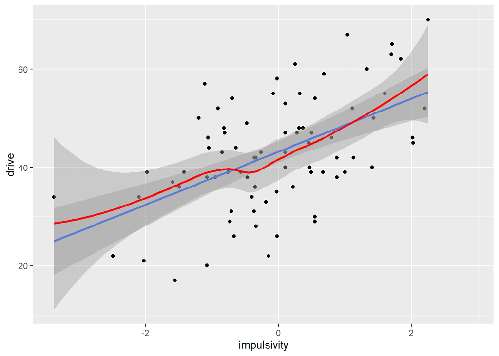

```r
tib2 %>%
  ggplot(., aes(x=impulsivity, y=drive)) +
  geom_point() +
  geom_smooth(method = "lm") +
  geom_smooth(method = "loess", col="red")
```

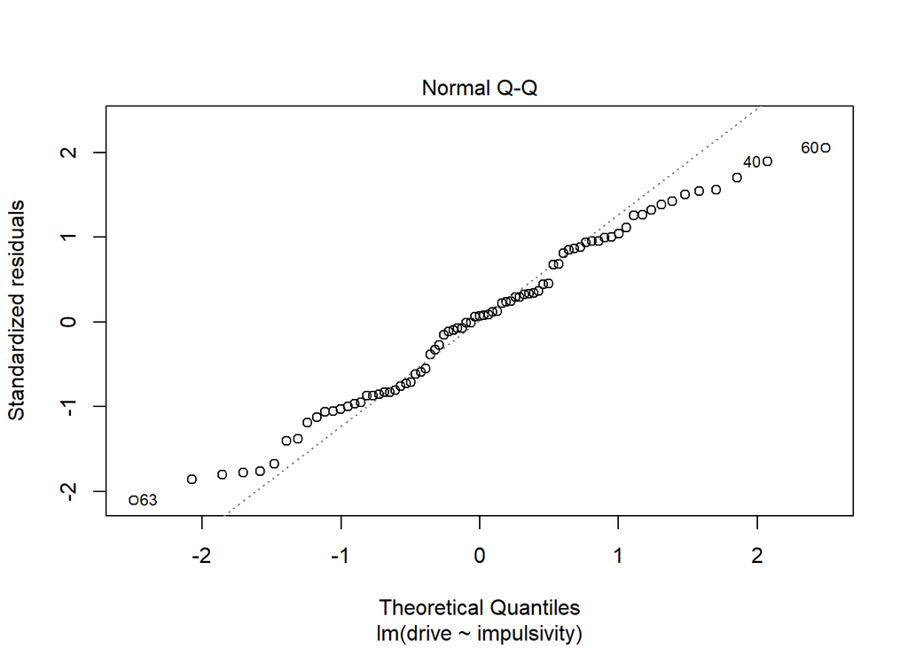

```r
plot(m1, which = 2)
```

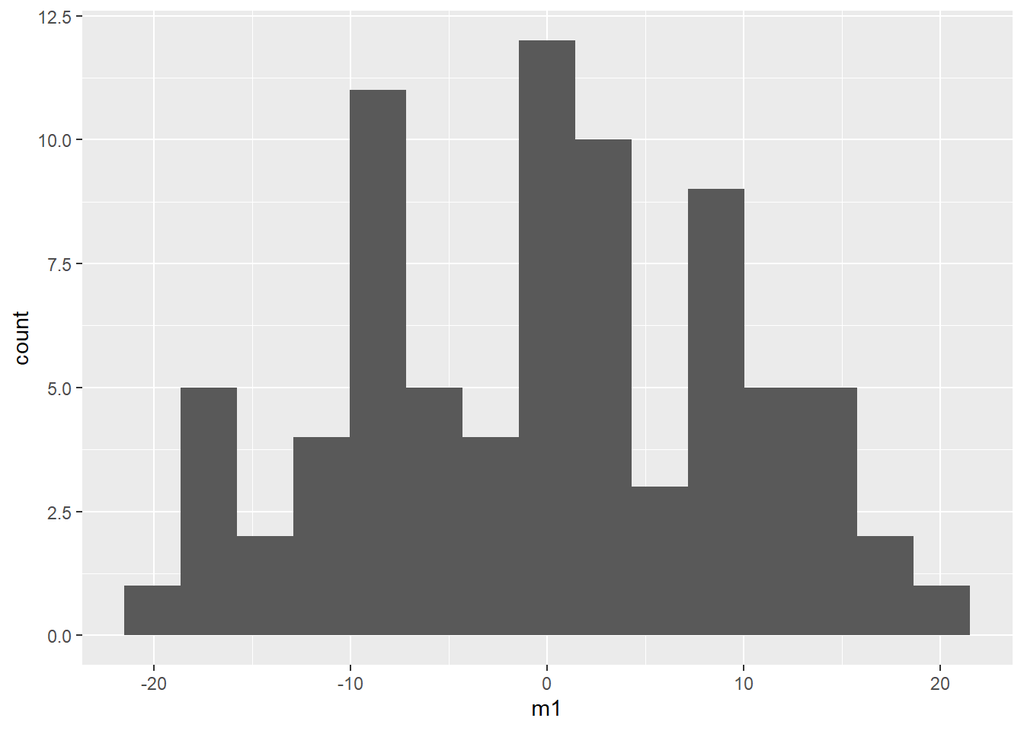

```r
res <- tibble(
  m1 = m1$residuals
)

res %>%
  ggplot(., aes(x=m1)) +
  geom_histogram(bins = 15)
```

```r
shapiro.test(m1$residuals)
```

```
##
##  Shapiro-Wilk normality test
##
## data:  m1$residuals
## W = 0.98019, p-value = 0.2577
```

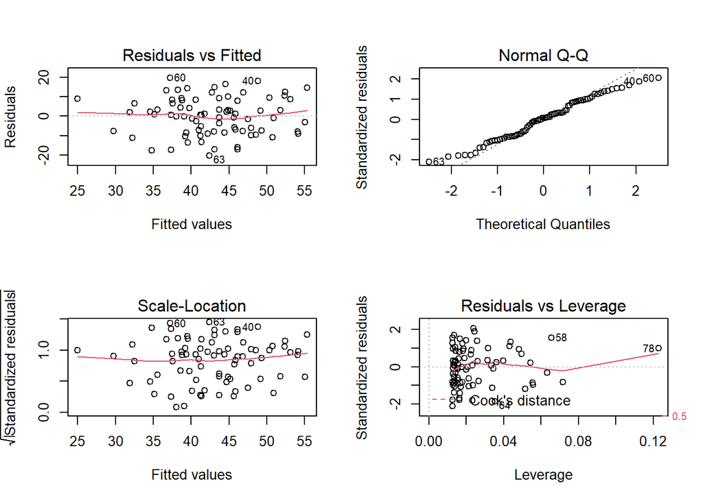

```r
par(mfrow = c(2,2))
plot(m1)
```

```r
ncvTest(m1)
```

```
## Non-constant Variance Score Test
## Variance formula: ~ fitted.values
## Chisquare = 1.521945e-05, Df = 1, p = 0.99689
```

```r
influence.measures(m1)
```

```
## Influence measures of
##   lm(formula = drive ~ impulsivity, data = tib2) :
##
##       dfb.1_  dfb.impl    dffit cov.r   cook.d    hat inf
## 1  -0.118301 -0.105935 -0.15524 1.024 1.21e-02 0.0237
## 2  -0.209385 -0.109296 -0.23188 0.960 2.61e-02 0.0163
## 3   0.013203  0.006333  0.01439 1.043 1.05e-04 0.0157
## 4  -0.094306 -0.058744 -0.10887 1.027 5.95e-03 0.0179
## 5   0.033273  0.012270  0.03496 1.039 6.18e-04 0.0144
## 6  -0.106548  0.013065 -0.10807 1.016 5.85e-03 0.0128
## 7  -0.061059  0.016319 -0.06400 1.032 2.07e-03 0.0135
## 8  -0.196709 -0.102679 -0.21784 0.969 2.32e-02 0.0163
## 9  -0.117199  0.072507 -0.14082 1.014 9.90e-03 0.0172
## 10  0.116052  0.180821  0.21048 1.054 2.22e-02 0.0483
## 11 -0.072486 -0.057785 -0.09067 1.039 4.14e-03 0.0213
```

[output cut: 68 more lines]

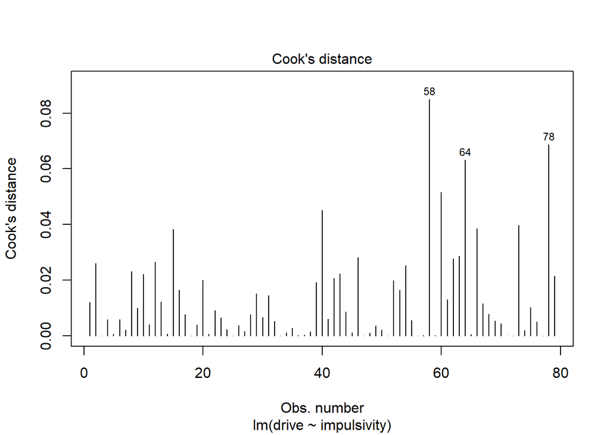

```r
plot(m1, which = 4)
```

## Question 1 interpretation

Let’s print the results again so it is easier to see the values:

```r
summary(m1)
```

```
##
## Call:
## lm(formula = drive ~ impulsivity, data = tib2)
##
## Residuals:
##      Min       1Q   Median       3Q      Max
## -20.3864  -7.9213   0.6384   8.2834  19.7914
##
## Coefficients:
##             Estimate Std. Error t value Pr(>|t|)
## (Intercept)  43.1954     1.0967  39.388  < 2e-16 ***
## impulsivity   5.3935     0.9715   5.552 3.86e-07 ***
## ---
## Signif. codes:  0 '***' 0.001 '**' 0.01 '*' 0.05 '.' 0.1 ' ' 1
##
## Residual standard error: 9.737 on 77 degrees of freedom
##   (1 observation deleted due to missingness)
## Multiple R-squared:  0.2859, Adjusted R-squared:  0.2766
## F-statistic: 30.82 on 1 and 77 DF,  p-value: 3.861e-07
```

## Question 2

2. Are there differences between young and old participants in risky driving behaviour? (week 5)

```r
m2 <- lm(drive ~ Age, data = tib)
summary(m2)
```

```
##
## Call:
## lm(formula = drive ~ Age, data = tib)
##
## Residuals:
##     Min      1Q  Median      3Q     Max
## -24.725  -6.927  -1.128   6.275  25.872
##
## Coefficients:
##             Estimate Std. Error t value Pr(>|t|)
## (Intercept)   41.725      1.812  23.032   <2e-16 ***
## AgeOld         2.403      2.578   0.932    0.354
## ---
## Signif. codes:  0 '***' 0.001 '**' 0.01 '*' 0.05 '.' 0.1 ' ' 1
##
## Residual standard error: 11.46 on 77 degrees of freedom
##   (1 observation deleted due to missingness)
## Multiple R-squared:  0.01116,    Adjusted R-squared:  -0.001686
## F-statistic: 0.8687 on 1 and 77 DF,  p-value: 0.3542
```

## Question 2 assumptions

For space, we will not run through the assumptions in full. But we would follow the steps above.

## Question 2 interpretation

The difference in risky driving score between young and old participants is non-significant ( $\beta$ = 2.4, $p = 0.354$ ). As such we fail to reject the null.

# IN THE INTEREST OF TIME, WE WILL NOT DO EVERYTHING WITHIN EACH OF THESE QUESTIONS, BUT WILL FOCUS ON THE “NEW” BITS OF CODING REQUIRED

## Question 3

**Are there differences in risky driving behaviour across experimental conditions?**

```r
tib2 <- na.omit(tib)
```

```r
m3 <- lm(drive ~ Condition, data = tib)
summary(m3)
```

```
##
## Call:
## lm(formula = drive ~ Condition, data = tib)
##
## Residuals:
##     Min      1Q  Median      3Q     Max
## -21.833  -7.237  -0.125   6.037  26.167
##
## Coefficients:
##             Estimate Std. Error t value Pr(>|t|)
## (Intercept)   36.350      2.298  15.816  < 2e-16 ***
## Condition1    10.050      3.250   3.092   0.0028 **
## Condition2    13.550      3.250   4.169 8.22e-05 ***
## Condition3     2.483      3.339   0.744   0.4594
## ---
## Signif. codes:  0 '***' 0.001 '**' 0.01 '*' 0.05 '.' 0.1 ' ' 1
##
## Residual standard error: 10.28 on 74 degrees of freedom
##   (2 observations deleted due to missingness)
## Multiple R-squared:  0.2334, Adjusted R-squared:  0.2023
## F-statistic:  7.51 on 3 and 74 DF,  p-value: 0.0001869
```

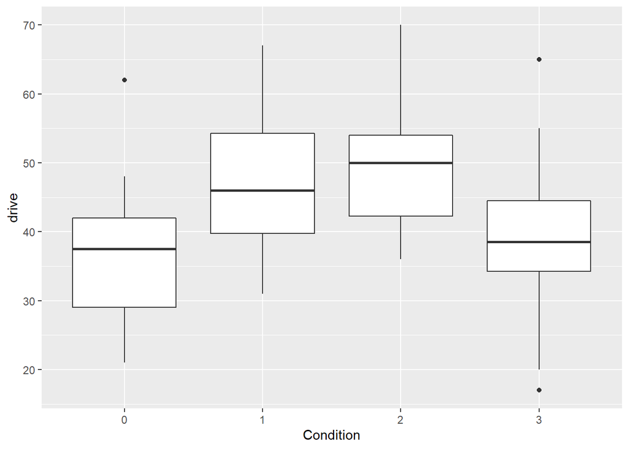

```r
tib2 %>%
  ggplot(., aes(x=Condition, y=drive)) +
  geom_boxplot()
```

```r
anova(m3)
```

```
## Analysis of Variance Table
##
## Response: drive
##           Df Sum Sq Mean Sq F value    Pr(>F)
## Condition  3 2380.3  793.43  7.5104 0.0001869 ***
## Residuals 74 7817.6  105.64
## ---
## Signif. codes:  0 '***' 0.001 '**' 0.01 '*' 0.05 '.' 0.1 ' ' 1
```

## Question 4

**Do the differences across experimental conditions remain the same after controlling for weight and impulsivity?**

```r
m4 <- lm(drive ~ weight + impulsivity + Condition, data = tib)
summary(m4)
```

```
##
## Call:
## lm(formula = drive ~ weight + impulsivity + Condition, data = tib)
##
## Residuals:
##     Min      1Q  Median      3Q     Max
## -15.986  -4.499  -1.524   5.699  18.288
##
## Coefficients:
##             Estimate Std. Error t value Pr(>|t|)
## (Intercept)   3.0772    12.0674   0.255  0.79945
## weight        0.4101     0.1446   2.837  0.00591 **
## impulsivity   5.2201     0.8140   6.413 1.31e-08 ***
## Condition1   12.3704     2.6118   4.736 1.06e-05 ***
## Condition2   12.1364     2.5542   4.752 1.00e-05 ***
## Condition3    2.8858     2.6295   1.097  0.27608
## ---
## Signif. codes:  0 '***' 0.001 '**' 0.01 '*' 0.05 '.' 0.1 ' ' 1
##
## Residual standard error: 8.033 on 72 degrees of freedom
##   (2 observations deleted due to missingness)
## Multiple R-squared:  0.5444, Adjusted R-squared:  0.5128
## F-statistic: 17.21 on 5 and 72 DF,  p-value: 3.624e-11
```

```r
anova(m4)
```

```
## Analysis of Variance Table
##
## Response: drive
##             Df Sum Sq Mean Sq F value    Pr(>F)
## weight       1  344.6  344.55  5.3399   0.02371 *
## impulsivity  1 2857.6 2857.64 44.2878 4.754e-09 ***
## Condition    3 2350.0  783.33 12.1401 1.619e-06 ***
## Residuals   72 4645.8   64.52
## ---
## Signif. codes:  0 '***' 0.001 '**' 0.01 '*' 0.05 '.' 0.1 ' ' 1
```

```r
summary(m4)
```

```
##
## Call:
## lm(formula = drive ~ weight + impulsivity + Condition, data = tib)
##
## Residuals:
##     Min      1Q  Median      3Q     Max
## -15.986  -4.499  -1.524   5.699  18.288
##
## Coefficients:
##             Estimate Std. Error t value Pr(>|t|)
## (Intercept)   3.0772    12.0674   0.255  0.79945
## weight        0.4101     0.1446   2.837  0.00591 **
## impulsivity   5.2201     0.8140   6.413 1.31e-08 ***
## Condition1   12.3704     2.6118   4.736 1.06e-05 ***
## Condition2   12.1364     2.5542   4.752 1.00e-05 ***
## Condition3    2.8858     2.6295   1.097  0.27608
## ---
## Signif. codes:  0 '***' 0.001 '**' 0.01 '*' 0.05 '.' 0.1 ' ' 1
##
## Residual standard error: 8.033 on 72 degrees of freedom
##   (2 observations deleted due to missingness)
## Multiple R-squared:  0.5444, Adjusted R-squared:  0.5128
## F-statistic: 17.21 on 5 and 72 DF,  p-value: 3.624e-11
```

Weight was a significant predictor of risky driving ( $\hat{\beta}$ = 0.41, $p<.05$ )

```r
m4_res <- summary(m4)$coefficients
```

Weight was a significant predictor of risky driving ( $\hat{\beta}$ = 0.41, $p$ = 0.006 )

## Question 5

**Does the effect of impulsivity on risking driving behaviour change as a function of age?**

```r
library(interactions)
```